# Ennakkotehtävä Risen erityisasiantuntijan haastatteluun

Tehtävän toteutuksen kuvaus

Antti Kääriälä

20.9.2021

Tässä dokumentissa kuvataan, miten olen tehnyt Risen erikoisasiantuntijan työhaastattelun ennakkotehtävän. Ennakkotahtävässä tulee esitellä graafisesti rikosoikeudellisessa vastuussa olevien ikäryhmien jakautumista Suomessa maakunnittain 2000-luvulla.

Tein ennakkotehtävän kokonaan R-ohjelmistolla. Ensin tein omat R-scriptit aineiston valmistelua ja kuvioiden tuottamista varten. Lopuksi valmistelin Power point -esityksen R Markdown’lla. Tämä dokumentti on jaettu näiden kolmen tehtäväkokonaisuuden mukaisesti kolmeen osaan: aineiston valmisteluun, kuvioiden tuottamiseen ja Power Point -esityksen kokoamiseen.

Power point -esityksen voi helposti päivittää suorittamalla tiedostot R:llä uudelleen, kun Tilastokeskuksen data päivittyy.

# 1. Aineiston tuottaminen

Tässä luvussa kuvataan aineiston valmistelu eli se, miten latasin aineiston Tilastokeskuksen tietokannasta ja muokkasin sen kuvioiden tuottamista varten.

Tiedot Suomen väestöstä vuosilta 2000–2020 saadaan Tilastokeskuksen PxWeb API-rajapinnan kautta. Tietoja ei näytä olevan saatavilla maakunnittain, joten ladataan tiedot kunnittain ja yhdistetään maakuntatieto myöhemmin aineistoon.

Tässä on aineiston lataamiseen käyttämäni koodi:

```r
setwd("~/polku_työkansioon")

# tarvittavat paketit

library(tidyverse)
library(lubridate)
library(pxweb)

# pxweb_get komennolle annettava kysely

vuodet <- as.character(c(2000:(year(Sys.Date()) - 1))) # poimittavat vuodet

query_vaesto <-
  list("Alue" = c("*"),
       "Ikä" = c("*"),
       "Sukupuoli" = c("SSS"),
       "Vuosi" = vuodet,
       "Tiedot" = c("vaesto"))

# aineiston lataaminen

px_data <-
  pxweb_get(url = "https://pxnet2.stat.fi/PXWeb/api/v1/fi/StatFin/vrm/vaerak/statfin_vaerak_pxt_11re.px",
            query = query_vaesto)

px_tibble <- as.data.frame(px_data,
                           column.name.type = "text",
                           variable.value.type = "text") %>% as_tibble()
```

Maakuntatiedon liittämiseen tarvittava kunta-maakunta-avain vuodelta 2021 löytyy Tilastokeskuksen sivustolta:

https://www2.stat.fi/fi/luokitukset/corrmaps/kunta_1_20210101%23maakunta_1_20210101/

```r
# Kunta-maakunta-datasta tarvitaan kahta muuttujaa:
# kuntaa(alue_kunta) ja maakuntaa (alue_mk)

kunta_maakunta <- read.csv("kunta_maakunta_2021.csv", sep = ";") %>% as_tibble()
```

Lopuksi liitetään kunta-maakunta avain PxWebistä ladattuun aineistoon ja muokataan data valmiiksi kuvien tuottamista varten.

```r
# tarkastelun ikäryhmät

ika_labs1 <- c(paste0("0\u2013", "14 v."),
              paste0("15\u2013", "17 v."),
              paste0("18\u2013", "20 v."),
              "Yli 20 v.")

ika_labs2 <- c(paste0("0\u2013", "11 v."),
              paste0("12\u2013", "14 v."),
              paste0("15\u2013", "17 v."),
              paste0("18\u2013", "20 v."),
              "Yli 20 v.")

# aineiston kasaaminen, muokkaus ja tallennus

vaesto_data <- px_tibble %>%
  filter(Ikä != "Yhteensä") %>%
  rename(alue_kunta = Alue) %>%
  left_join(kunta_maakunta, by = "alue_kunta") %>%
  rename(vaesto = `Väestö 31.12.`,
         maakunta = alue_mk,
         ika = Ikä,
         vuosi = Vuosi) %>%
  mutate(ika = str_replace(ika, " -", "")) %>%
  mutate(vuosi = as.integer(vuosi),
         ika = as.integer(ika),
         maakunta = as.factor(maakunta)) %>%
  count(maakunta, vuosi, ika, wt = vaesto, name = "vaesto") %>%
  mutate(ika_lk1 = cut(ika,
                      breaks = c(min(ika), 14, 17, 20, max(ika)),
                      include.lowest = TRUE,
                      labels = ika_labs1)) %>%
  mutate(ika_lk2 = cut(ika,
                      breaks = c(min(ika), 11, 14, 17, 20, max(ika)),
                      include.lowest = TRUE,
                      labels = ika_labs2)) %>%
  arrange(maakunta, vuosi, ika)

saveRDS(vaesto_data, file = "vaesto_data.rds")
```

# 2. Kuvioiden tuottaminen

Seuraavassa scriptissä on kaikki Power point -esityksen kuvioiden tuottamiseen tarvittava koodi.

```r
setwd("~/polku_työkansioon")

# tarvittavat paketit

library(tidyverse)
library(viridis)
library(lubridate)

# aineiston lataaminen

vaesto_data <- read_rds("vaesto_data.rds")



# Kuviot ------------------------------------------------------------------

# kuvioiden yl. asetukset

lahde <- expression(paste(italic("Lähde:"), "Tilastokeskus"))
font_size <- 14
p_width <- 9
p_height <- 5



# Aluekuvio koko maan kaikista ikäryhmistä --------------------------------

p_kokovaesto <- vaesto_data %>%
  count(maakunta, ika_lk1, vuosi, wt = vaesto, name = "vaesto") %>%
  filter(maakunta == "Koko Suomi") %>%
  ggplot(aes(x = vuosi, y = vaesto)) +
  geom_area(aes(fill = fct_rev(ika_lk1)), alpha = 0.6, color = "white")+
  theme_minimal() +
  theme(plot.margin = margin(1, 1, 1, 1, unit = 'pt'),
        text = element_text(size = font_size)) +
  labs(x = NULL,
       y = "Väestö, miljoonaa henkilöä",
       caption = lahde) +
  scale_y_continuous(expand = c(0, 0),
                     limits = c(0, 5600000),
                     breaks = seq(1000000, 5600000, 1000000),
                     labels = scales::number_format(scale = 1 / 1000000,
                                                    accuracy = 1,
                                                    big.mark = " ")) +
  scale_fill_brewer(direction = -1, name = "Ikä:")

ggsave("kokovaesto.png", width = p_width, height = p_height)



# Aluekuvio rikosvastuuikäisen väestön jakautumisesta maakunnittain -------

n_pop <- vaesto_data %>%
  filter(maakunta == "Koko Suomi" & ika_lk1 != "0–14 v.") %>%
  count(vuosi, wt = vaesto, name = "n_pop")

mk_rvpopdist <- vaesto_data %>%
  filter(maakunta != "Koko Suomi" & ika_lk1 != "0–14 v.") %>%
  count(maakunta, vuosi, wt = vaesto, name = "vaesto") %>%
  left_join(n_pop, by = "vuosi") %>%
  mutate(pop_osuus = vaesto / n_pop) %>%
  ggplot(aes(x = vuosi, y = pop_osuus)) +
  geom_area(aes(fill = fct_reorder(maakunta, vaesto)),
            alpha = 0.7, color = "white") +
  theme_minimal() +
  theme(plot.margin = margin(1, 1, 1, 1, unit = 'pt'),
        text = element_text(size = font_size),
        panel.grid.major = element_line(size = 1),
        legend.title = element_blank()) +
  labs(x = NULL,
       y = "Osuus väestöstä, %",
       caption = lahde) +
  scale_y_continuous(expand = c(0, 0.01),
                     breaks = seq(0, 1, 0.2),
                     minor_breaks = seq(0, 1, 0.1),
                     labels = scales::percent_format(suffix = "")) +
  scale_fill_viridis(option = "cividis", discrete = TRUE, direction = -1)

ggsave("mk_rvpopdist.png", width = p_width, height = p_height)



# Aluekuvio rv-ikäisten jakaumasta ikäluokittain --------------------------

ika_rvpopdist <- vaesto_data %>%
  filter(maakunta != "Koko Suomi" & ika_lk1 != "0–14 v.") %>%
  count(ika_lk1, vuosi, wt = vaesto, name = "vaesto") %>%
  left_join(n_pop, by = "vuosi") %>%
  mutate(pop_osuus = vaesto / n_pop) %>%
  ggplot(aes(x = vuosi, y = pop_osuus)) +
  geom_area(aes(fill = fct_reorder(ika_lk1, vaesto) %>% fct_rev()),
            alpha = 0.7, color = "white") +
  theme_minimal() +
  theme(plot.margin = margin(1, 1, 1, 1, unit = 'pt'),
        text = element_text(size = font_size),
        panel.grid.major = element_line(size = 1)) +
  labs(x = NULL,
       y = "Osuus väestöstä, %",
       caption = lahde) +
  scale_y_continuous(expand = c(0, 0.01),
                     breaks = seq(0, 1, 0.2),
                     minor_breaks = seq(0, 1, 0.1),
                     labels = scales::percent_format(suffix = "")) +
  scale_fill_brewer(name = "Ikä:")

ggsave("ika_rvpopdist.png", width = p_width, height = p_height)



# Rikosvastuuikäisen väestön määrän muutokset maakunnittain ---------------

# Kuvioissa piirretään havainnot kolmelle vuodelle:
# seurannan alkuvuodelle, puoliväliin ja loppuun
# eli vuonna 2021 vuodet ovat: 2000, 2010, 2020

p_vuodet <- c(2000,
              2000 + floor(((year(Sys.Date()) - 1) - 2000) / 2),
              year(Sys.Date()) - 1)

# rajataan maakuntakuvioiden aineisto

p_data <- vaesto_data %>%
  filter(maakunta != "Koko Suomi" & vuosi %in% p_vuodet) %>%
  count(maakunta, ika_lk1, vuosi, wt = vaesto, name = "vaesto")

# koko rikosvastuuikäinen väestö eli 15 +

rvpop_data <- p_data %>%
  filter(ika_lk1 != "0–14 v.") %>%
  count(maakunta, vuosi, wt = vaesto)

mk_rvpop <- rvpop_data %>%
  ggplot(aes(fct_reorder(maakunta, n), n)) +
  geom_point(aes(color = as_factor(vuosi)), alpha = 0.6, size = 4) +
  coord_flip() +
  theme_minimal() +
  theme(panel.grid.major.y = element_blank(),
        panel.grid.minor.y = element_blank(),
        panel.grid.major = element_line(size = 1),
        legend.justification = c(1, 0),
        legend.position = c(1, 0.05),
        legend.title = element_blank(),
        legend.direction = "horizontal",
        plot.margin = margin(1, 15, 1, 1, unit = 'pt'),
        text = element_text(size = font_size)) +
  labs(x = NULL, y = NULL,
       caption = lahde) +
  scale_y_continuous(expand = c(0, 10000),
                     limits = c(0, max(rvpop_data$n) + 100000),
                     breaks = seq(0, max(rvpop_data$n) + 100000, 250000),
                     minor_breaks = seq(0, max(rvpop_data$n)+ 100000, 125000),
                     labels = scales::number_format(big.mark = " ")) +
  scale_color_viridis(discrete = TRUE, direction = -1)

ggsave("mk_rvpop.png", width = p_width, height = p_height)

# aikuiset eli yli 20 v

aikuisten_data <- p_data %>%
  filter(ika_lk1 == "Yli 20 v.") %>%
  count(maakunta, vuosi, wt = vaesto)

mk_aik <- aikuisten_data %>%
  ggplot(aes(fct_reorder(maakunta, n), n)) +
  geom_point(aes(color = as_factor(vuosi)), alpha = 0.6, size = 4) +
  coord_flip() +
  theme_minimal() +
  theme(panel.grid.major.y = element_blank(),
        panel.grid.minor.y = element_blank(),
        panel.grid.major = element_line(size = 1),
        legend.justification = c(1, 0),
        legend.position = c(1, 0.05),
        legend.title = element_blank(),
        legend.direction = "horizontal",
        plot.margin = margin(1, 15, 1, 1, unit = 'pt'),
        text = element_text(size = font_size)) +
  labs(x = NULL, y = NULL,
       caption = lahde) +
  scale_y_continuous(expand = c(0, 0),
                     limits = c(0, max(aikuisten_data$n + 100000)),
                     breaks = seq(0, max(aikuisten_data$n) + 100000, 250000),
                     minor_breaks = seq(0, max(aikuisten_data$n)+ 100000, 125000),
                     labels = scales::number_format(big.mark = " ")) +
  scale_color_viridis(discrete = TRUE, direction = -1)

ggsave("mk_aik.png", width = p_width, height = p_height)

# nuoret eli 15 - 20 v

nuorten_data <- p_data %>%
  filter(ika_lk1 %in% c("15–17 v.", "18–20 v.")) %>%
  count(maakunta, vuosi, wt = vaesto)

mk_nuoret <- nuorten_data %>%
  ggplot(aes(fct_reorder(maakunta, n), n)) +
  geom_point(aes(color = as_factor(vuosi)), alpha = 0.6, size = 4) +
  coord_flip() +
  theme_minimal() +
  theme(panel.grid.major.y = element_blank(),
        panel.grid.minor.y = element_blank(),
        panel.grid.major = element_line(size = 1),
        legend.justification = c(1, 0),
        legend.position = c(1, 0.05),
        legend.title = element_blank(),
        legend.direction = "horizontal",
        plot.margin = margin(1, 15, 1, 1, unit = 'pt'),
        text = element_text(size = font_size)) +
  labs(x = NULL, y = NULL,
       caption = lahde) +
  scale_y_continuous(expand = c(0, 0),
                     limits = c(0, max(nuorten_data$n) + 10000),
                     breaks = seq(0, max(nuorten_data$n) + 10000, 20000),
                     minor_breaks = seq(0, max(nuorten_data$n)+ 10000, 10000),
                     labels = scales::number_format(big.mark = " ")) +
  scale_color_viridis(discrete = TRUE, direction = -1)

ggsave("mk_nuoret.png", width = p_width, height = p_height)



# Ennuste 2023: alaikäisten rikosvastuuikäisten määrän muutos --------------

ennuste_data <- vaesto_data %>%
  filter(vuosi == year(Sys.Date()) - 1) %>%
  filter(maakunta != "Koko Suomi" & ika_lk2 %in% c("12–14 v.", "15–17 v.")) %>%
  count(maakunta, ika_lk2, wt = vaesto)

ennuste <- ennuste_data %>%
  ggplot(aes(fct_reorder(maakunta, n), n)) +
  geom_point(aes(color = as_factor(ika_lk2)), alpha = 0.6, size = 4) +
  coord_flip() +
  theme_minimal() +
  theme(panel.grid.major.y = element_blank(),
        panel.grid.minor.y = element_blank(),
        panel.grid.major = element_line(size = 1),
        legend.justification = c(1, 0),
        legend.position = c(1, 0.05),
        legend.title = element_blank(),
        legend.direction = "horizontal",
        plot.margin = margin(1, 15, 1, 1, unit = 'pt'),
        text = element_text(size = font_size)) +
  labs(x = NULL, y = NULL,
       caption = lahde) +
  scale_y_continuous(expand = c(0, 0),
                     limits = c(0, max(ennuste_data$n) + 5000),
                     breaks = seq(0, max(ennuste_data$n) + 10000, 10000),
                     minor_breaks = seq(0, max(ennuste_data$n)+ 10000, 5000),
                     labels = scales::number_format(big.mark = " ")) +
  scale_color_brewer(labels = c("Ennuste 2023", "2000"),
                     guide = guide_legend(reverse = TRUE),
                     palette = "Set1")

ggsave("ennuste.png", width = p_width, height = p_height)
```

# 3. Esityksen kokoaminen

Kokosin esityksen alla olevalla R Markdown-koodilla kirjoittamalla kalvojen tekstit markdown-pohjaan ja poimimalla edellä tallennetut kuviot esitykseen.

```r
knitr::opts_chunk$set(echo = FALSE, message = FALSE, warning = FALSE,
  dev = "png", fig.width = 8, fig.height = 5)
```

## Esityksen tarkoitus

- Antaa käsitys rikosoikeudellisessa vastuussa olevien ikäryhmien jakautumisesta Suomessa maakunnittain 2000-luvulla.
- Rikosoikeudellinen vastuu alkaa 15-vuotiaana.
- Tarkasteltavat ikäryhmät: 15–17-vuotiaat, 18–20-vuotiaat ja yli 20-vuotiaat.

## Suomen väestö kasvanut hieman 2000-luvun aikana

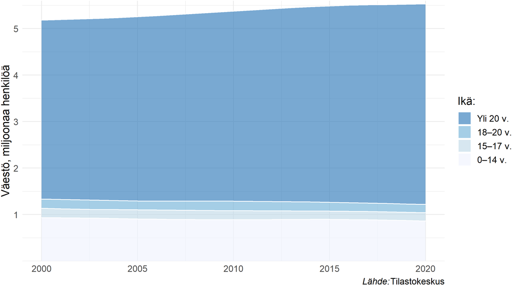

```r
knitr::include_graphics("kokovaesto.png")
```

## Rikosoikeudellisessa vastuussa oleva väestö eli 15 vuotta täyttäneet maakunnittain, määrät

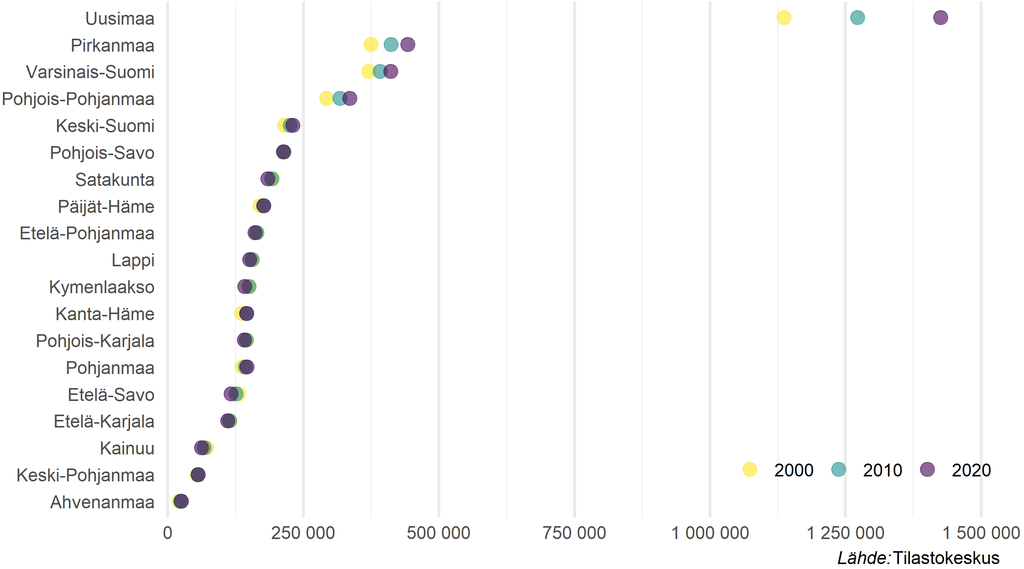

```r
knitr::include_graphics("mk_rvpop.png")
```

## Rikosoikeudellisessa vastuussa oleva väestö eli 15 vuotta täyttäneet maakunnittain, jakauma

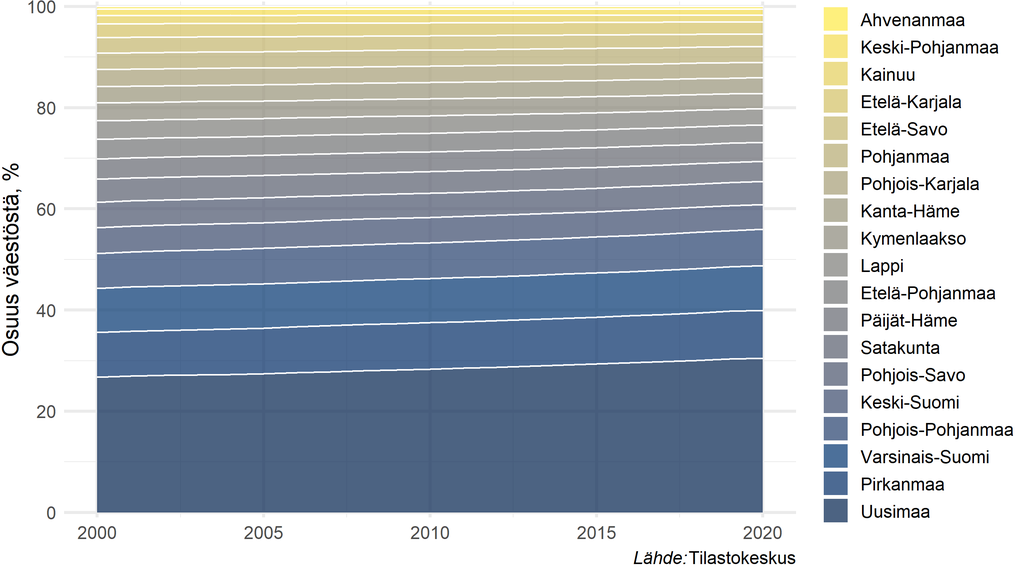

```r
knitr::include_graphics("mk_rvpopdist.png")
```

## Aikuisväestö eli yli 20-vuotiaat kasvanut eniten Uudellamaalla

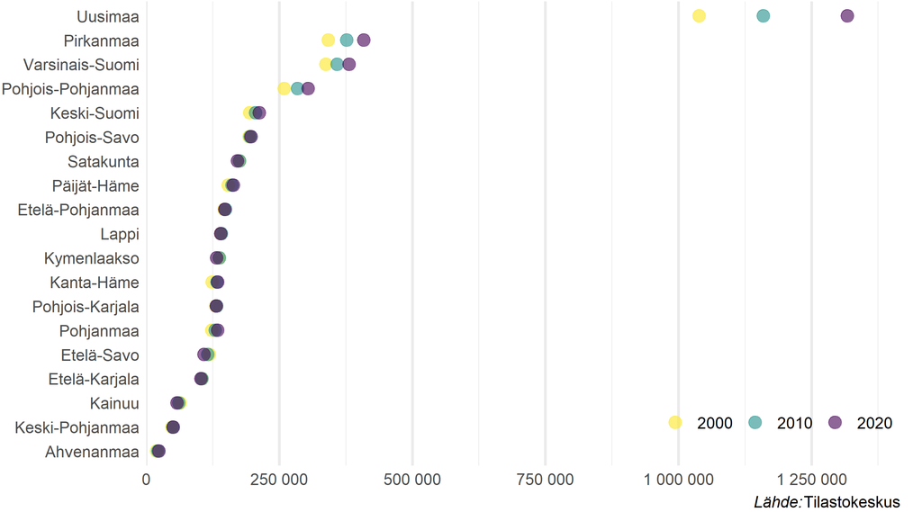

```r
knitr::include_graphics("mk_aik.png")
```

## Nuorisoikäinen väestö eli 15–20-vuotiaat vähentynyt useimmissa maakunnissa

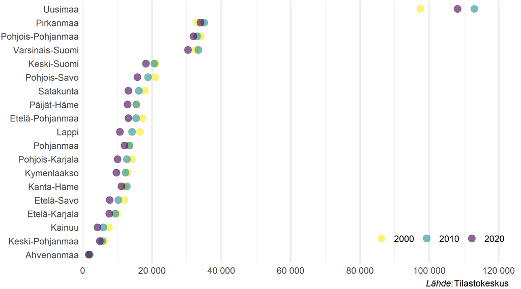

```r
knitr::include_graphics("mk_nuoret.png")
```

## Rikosoikeudellisessa vastuussa olevasta väestöstä eli 15 vuotta täyttäneistä alle 10 % nuorisoikäisiä

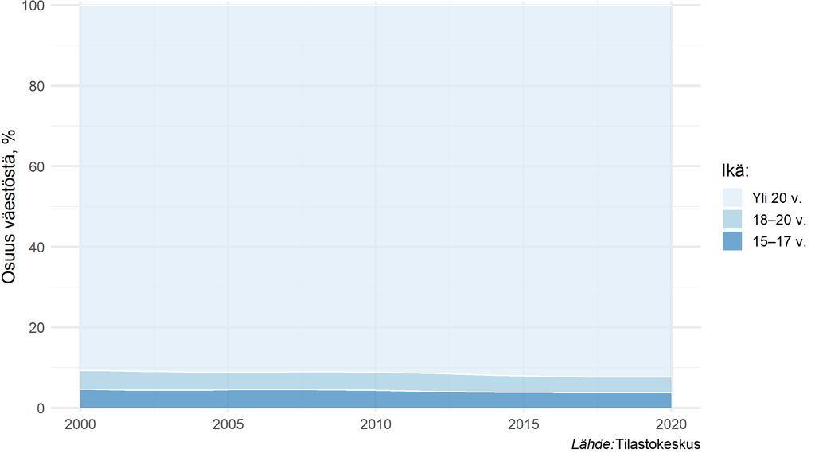

```r
knitr::include_graphics("ika_rvpopdist.png")
```

## Ennuste: 15–17-vuotiaiden määrä kasvaa lähinnä Uudellamaalla

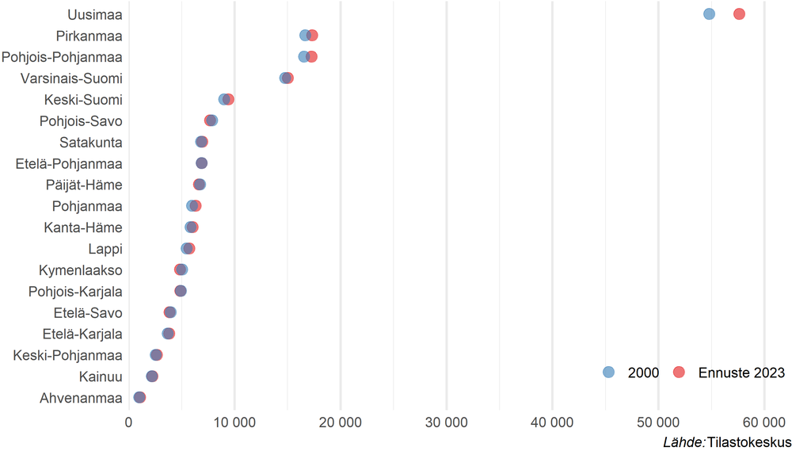

```r
knitr::include_graphics("ennuste.png")
```

```r
# poimitaan johtopäätösdiaan väestön koko viimeisenä seurantavuotena

library(tidyverse)

vaesto_data <- readr::read_rds("vaesto_data.rds")

vika_vuosi <- max(vaesto_data$vuosi)

rv_pop <- round(vaesto_data %>% filter(maakunta == "Koko Suomi" & vuosi == vika_vuosi & ika_lk1 != "0–14 v.") %>% count(vuosi, wt = vaesto) %>% pull(n) / 1000000, 1) %>% as.character() %>% str_replace(., "[.]", ",")
```